# Brain Controlled Wheelchair

2017-10-31T22:42:51-05:00

Millions of people across the world suffer from various mobility impairments caused by Amyotrophic Lateral Sclerosis (ALS), brainstem stroke, brain or spinal cord injury, cerebral palsy, muscular dystrophies, multiple sclerosis, and many other diseases. A large portion of these people heavily rely upon wheelchairs to get on with their day to day activities.

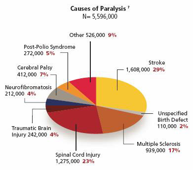

These people are dependent on others in order to move. A large number of patients are not prescribed wheelchairs at all, because they find it physically difficult to control the manual wheelchair. In our work with Brain Controlled Wheelchairs, we target a population who are—or will become—unable to use conventional interfaces, due to severe motor–disabilities.

In order to assist people with mobility impairments to move in an autonomous way and also to lighten the duties of those who assist them, we propose to make a Brain Controlled Wheelchair.

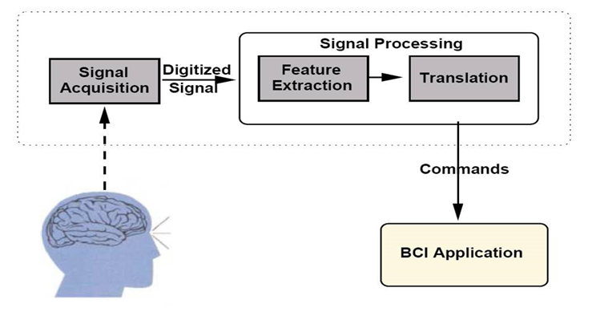

The proposed work is to develop a smart wheelchair that uses EEG Signals in order to trigger the wheelchair. The system uses a Brainwave Headset to capture the Attention Levels of the user using Electroencephalography (EEG) Technique and Eye Blinks of a person using the Electromyography (EMG) Technique .

This data is processed to extract the required features and classified as threshold based commands to operate the wheelchair

[figure not shown]

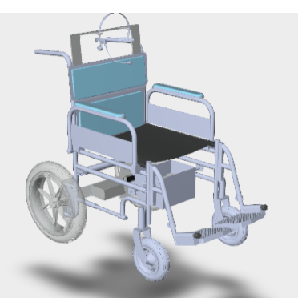

Click Here for Project PDF: [link](https://drive.google.com/file/d/1Yn-UhC_XAouQYf5wFPs9Y_y38_IM1H91/view?usp=sharing)

Click Here for Presentation: [link](https://docs.google.com/presentation/d/1FTcLrRrJPZX1m-lG9Iu9BEeIZAawK42Y/edit?usp=sharing&ouid=108173321706988539876&rtpof=true&sd=true)